# Real-data prep — MacroSheds P→Q (daily) and C→Q (native-cadence) series

Builds the tracked per-site CSVs that analyses 03/04 (precip→discharge) and 05 (nitrate→discharge) read

nic (nic@cascadeclimate.org)

2026-07-18

This notebook is the **real-data analog of `syn_data/make_synthetic.Rmd`**: it does not analyze anything, it just assembles the tracked datasets that `analysis_03` / `analysis_04` consume. The synthetic generator invents a clean lagged log-linear system; here we instead **carve real MacroSheds watershed records into the same wide `climate / response / phase` shape**, so the two legs of the study feed identical analysis code (the whole point — a clean methods comparison; see `CLAUDE.md`).

**Channel mapping** (see `../CLAUDE.md` for the full rationale):

- `climate` = **daily precipitation (mm)** — the exogenous, *undisturbed* driver (the analog of the synthetic sine). Kept in **linear** units: precip is non-negative and spiky, its many zero-rain days are genuine, and no log is taken on the driver.
- `response` = **daily discharge (L/s)** — the disturbed variable, analyzed in **log space** by 03/04 (strictly positive, right-skewed, multiplicative). We floor zero-flow days here so `log(response)` is always finite (below).
- `phase` = ordered `pre → disturbance → post`, cut from each site’s screened disturbance date and window in `../qualifying_disturbances.csv`.

Unlike the synthetic ideal, real precip is **episodic (not a clean annual sine)**, discharge carries **trend / storage / snowmelt lag**, and one site’s stream is **intermittent** — exactly the less-deterministic synchrony 03/04 stress-test the two methods against.

## Inputs & site table

```r
# The 5 screened disturbances (one per site) with their pre/post windows.
qd <- read_csv("../qualifying_disturbances.csv", show_col_types = FALSE) %>%
  mutate(tag = paste0(domain, "_", site_code))
kable(qd %>% select(tag, disturbance, class, disturbance_start, disturbance_end,
                    window_start, window_end),
      caption = "The 5 qualifying real disturbances (source: ../qualifying_disturbances.csv)")
```

The 5 qualifying real disturbances (source: ../qualifying_disturbances.csv)

| tag | disturbance | class | disturbance_start | disturbance_end | window_start | window_end |
| --- | --- | --- | --- | --- | --- | --- |
| hbef_w1 | chemical_addition | pulse | 1999-11-01 | 1999-11-01 | 1983-11-01 | 2022-11-01 |
| hjandrews_GSWS10 | debris_flow | pulse | 1986-02-01 | 1986-02-01 | 1976-02-01 | 2019-02-01 |
| fernow_WS-3 | chemical_addition | chronic | 1989-01-01 | 1989-01-01 | 1971-01-01 | 2020-01-01 |
| fernow_WS-5 | timber_harvest | pulse | 2007-01-01 | 2007-04-01 | 1991-01-01 | 2019-04-01 |
| santa_barbara_MC06 | burn | pulse | 2009-05-10 | 2009-05-10 | 1998-05-10 | 2021-05-10 |

## Build one wide series per site

For each site we (1) intersect its qualifying window with the dates where **both** precip and discharge exist (this trims `santa_barbara_MC06` — precip starts 2000 — and `hjandrews_GSWS10` — precip ends 2017), (2) lay both channels on a **continuous daily grid** (both are already gap-free inside the window, verified — no interpolation), (3) **floor zero-flow days** to half the 1st-percentile of positive discharge (robust to near-zero traces) so `log(response)` is finite (flagged in `zero_flow`), and (4) label `phase` from the disturbance dates. `time` is an integer day index `1…N` — the unit all the ported peak / wavelet math runs in (`dt = 1` day).

```r
build_site <- function(row) {
  tag <- row$tag
  q <- read_csv(sprintf("../data/%s__discharge_daily.csv",    tag), show_col_types = FALSE)
  p <- read_csv(sprintf("../data/%s__precipitation_daily.csv", tag), show_col_types = FALSE)

  lo <- max(row$window_start, min(q$date), min(p$date))    # common, window-clipped span
  hi <- min(row$window_end,   max(q$date), max(p$date))
  grid <- tibble(date = seq(lo, hi, by = "day"))

  # carry MacroSheds' gap-fill flag (ms_interp == 1) for both channels. Discharge is fully
  # observed at all 5 sites; precipitation is partly modelled-infill at some (hjandrews ~13%,
  # MC06 ~88%) — surfaced here and flagged per row so the analyses can caveat it.
  qv <- q %>% filter(date >= lo, date <= hi) %>% transmute(date, discharge = val, q_interp = ms_interp == 1)
  pv <- p %>% filter(date >= lo, date <= hi) %>% transmute(date, precip    = val, p_interp = ms_interp == 1)
  d  <- grid %>% left_join(qv, by = "date") %>% left_join(pv, by = "date")

  # Corrupt-precip guard. MacroSheds' Santa Barbara (MC06) precip carries impossible gap-fill
  # spikes (~6.15e6 mm/d, all ms_interp == 1); real daily precip here is < 170 mm/d. Flag values
  # > 500 mm/d, blank them, and linearly interpolate on the daily grid so the driver stays
  # continuous (WaveletComp needs a gap-free series). Only MC06 is affected; harmless elsewhere.
  d$climate_corrupt <- !is.na(d$precip) & d$precip > 500
  d$precip[d$climate_corrupt] <- NA_real_
  if (anyNA(d$precip)) d$precip <- approx(seq_len(nrow(d)), d$precip, seq_len(nrow(d)), rule = 2)$y

  # log floor = half the 1st-percentile of positive flow. Robust to near-zero trace values (e.g.
  # hbef has positive readings ~3e-5 L/s); flooring at the raw minimum would put no-flow days at an
  # absurd log outlier (~ -11) that dominates the variance. The 1st-pct floor keeps them "very low".
  eps <- 0.5 * as.numeric(quantile(d$discharge[d$discharge > 0], 0.01, na.rm = TRUE))
  ds <- row$disturbance_start; de <- row$disturbance_end
  d %>% transmute(
    time     = row_number(),
    date,
    climate  = precip,                                   # linear driver (mm)
    response = pmax(discharge, eps),                     # floored discharge (L/s), strictly positive
    zero_flow = discharge <= 0,                          # days that were floored (intermittent flow)
    climate_interp  = p_interp,                          # precip day is MacroSheds gap-fill (modelled)
    climate_corrupt = climate_corrupt,                   # precip day was an impossible spike, blanked+interpolated (MC06 only)
    response_interp = q_interp,                          # discharge day is gap-fill (0% at every site)
    phase = factor(ifelse(date < ds, "pre",
                   ifelse(date <= de, "disturbance", "post")),
                   levels = c("pre", "disturbance", "post")),
    site  = tag,
    disturbance = row$disturbance,                       # carried so 03/04 need no external file
    class = row$class)
}

series <- lapply(seq_len(nrow(qd)), function(i) build_site(qd[i, ]))
names(series) <- qd$tag
```

## Write the tracked CSVs & summary

```r
paths <- vapply(names(series), function(tag) {
  f <- file.path(OUT_DIR, paste0(tag, "__series_daily.csv"))
  # response rounded to 6 dp (not 4): some sites have sub-1e-4 flows that 4 dp would zero out → -Inf in log.
  write_csv(series[[tag]] %>% mutate(climate = round(climate, 4), response = round(response, 6)), f)
  f
}, character(1))

summ <- bind_rows(lapply(series, function(s) tibble(
  site = s$site[1], class = s$class[1], n_days = nrow(s),
  start = min(s$date), end = max(s$date),
  pre_days  = sum(s$phase == "pre"),
  post_days = sum(s$phase == "post"),
  zero_flow_days = sum(s$zero_flow),
  climate_corrupt_days = sum(s$climate_corrupt),                  # impossible precip spikes blanked+interpolated (MC06 only)
  climate_interp_pct  = round(100 * mean(s$climate_interp), 1),   # % of precip days that are modelled infill
  response_interp_pct = round(100 * mean(s$response_interp), 1),  # % of discharge days infilled (≈0)
  med_climate = median(s$climate), med_response = median(s$response))))
kable(summ, digits = 2, caption = "Wide series written to ms_data/ (one row per site)")
```

Wide series written to ms_data/ (one row per site)

| site | class | n_days | start | end | pre_days | post_days | zero_flow_days | climate_corrupt_days | climate_interp_pct | response_interp_pct | med_climate | med_response |
| --- | --- | --- | --- | --- | --- | --- | --- | --- | --- | --- | --- | --- |
| hbef_w1 | pulse | 14246 | 1983-11-01 | 2022-11-01 | 5844 | 8401 | 160 | 0 | 0.0 | 0 | 0.06 | 1.47 |
| hjandrews_GSWS10 | pulse | 15040 | 1976-02-01 | 2017-04-05 | 3653 | 11386 | 40 | 0 | 13.4 | 0 | 0.02 | 1.44 |
| fernow_WS-3 | chronic | 17897 | 1971-01-01 | 2019-12-31 | 6575 | 11321 | 93 | 0 | 0.0 | 0 | 0.00 | 3.75 |
| fernow_WS-5 | pulse | 10318 | 1991-01-01 | 2019-04-01 | 5844 | 4383 | 113 | 0 | 0.0 | 0 | 0.00 | 4.50 |
| santa_barbara_MC06 | pulse | 7527 | 2000-10-01 | 2021-05-10 | 3143 | 4383 | 446 | 66 | 87.6 | 0 | 0.00 | 2.83 |

**Data-provenance note (`ms_interp`).** Discharge is **fully observed** (0% gap-filled) at every site — the `log(response)` channel is real throughout. Precipitation, however, is partly **MacroSheds modelled infill**: negligible at `hbef_w1` / `fernow_WS-3` / `fernow_WS-5`, ~13% at `hjandrews_GSWS10`, and **~88% at `santa_barbara_MC06`** (its precip driver is almost entirely gap-filled — treat any MC06 precip→discharge coupling as coupling to a *modelled* driver, not an observed one). Analyses 03/04 repeat this caveat where it matters.

## Sanity panels

Climate (precip, top) and `log(response)` (log discharge, bottom) per site, phases shaded, the disturbance drawn as a dashed line. This is the same view `analysis_03` opens each site section with — here purely to confirm the join, phase cut, and log-floor look right.

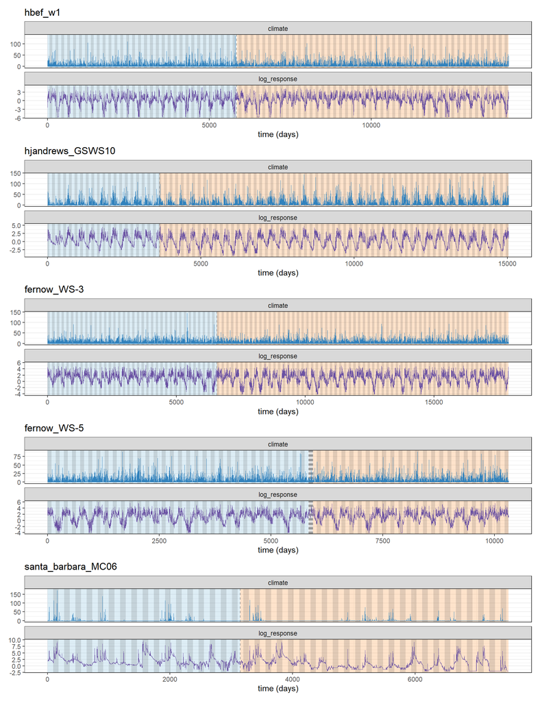

Figure 1. Per-site assembled series: precip (blue) and log(discharge) (purple), pre/post shaded, dashed = disturbance date. Note the episodic precip driver and, at MC06, the intermittent-flow floor in log space.

```r
phase_fill <- c(pre = "#9ecae1", disturbance = "grey45", post = "#fdae6b")
# alternating calendar-quarter (3-month "season") shading in the plot's x units — light seasonal
# reference over the phase bands (needs a `date` column). Shared by both panel sets below.
season_layer <- function(d, xcol) {
  q  <- (as.integer(format(d$date, "%m")) - 1) %/% 3 + 1
  yr <- as.integer(format(d$date, "%Y"))
  r  <- tibble(x = d[[xcol]], qi = yr * 4 + q, q = q) %>%
    group_by(qi) %>% summarise(xmin = min(x), xmax = max(x), odd = first(q) %% 2 == 1, .groups = "drop") %>%
    filter(odd)
  geom_rect(data = r, aes(xmin = xmin, xmax = xmax, ymin = -Inf, ymax = Inf),
            fill = "grey20", alpha = 0.14, inherit.aes = FALSE)
}
one_panel <- function(s) {
  bands <- s %>% filter(phase != "disturbance") %>% group_by(phase) %>%
    summarise(xmin = min(time), xmax = max(time), .groups = "drop")
  td <- s$time[s$phase == "disturbance"]
  long <- s %>% transmute(time, climate, log_response = log(response)) %>%
    pivot_longer(c(climate, log_response), names_to = "var")
  ggplot() +
    geom_rect(data = bands, aes(xmin = xmin, xmax = xmax, ymin = -Inf, ymax = Inf, fill = phase),
              alpha = 0.35, inherit.aes = FALSE) +
    season_layer(s, "time") +
    geom_vline(xintercept = td, linetype = 2, colour = "grey60") +
    geom_line(data = long, aes(time, value, colour = var), linewidth = 0.2) +
    facet_wrap(~ var, ncol = 1, scales = "free_y") +
    scale_fill_manual(values = phase_fill, guide = "none") +
    scale_colour_manual(values = c(climate = "#3182bd", log_response = "#6a51a3"), guide = "none") +
    labs(title = s$site[1], x = "time (days)", y = NULL)
}
wrap_plots(lapply(series, one_panel), ncol = 1)
```

The five `*__series_daily.csv` files are the **P→Q interface** between this prep and analyses 03/04 — exactly as `synthetic_*.csv` are for `syn_data`.

# C→Q series (nitrate concentration → discharge)

The second leg (analysis 05) is the **concentration–discharge (C–Q)** relationship: driver = discharge `Q`, response = **stream nitrate concentration `C`** — a noisier, *less causal* coupling (nitrate is only partly set by flow; sources, hysteresis, dilution-vs-flushing all intervene). It is the real-data stress-test of the wavelet method against a weaker signal.

Unlike precip/discharge, **nitrate is irregular grab samples** (weekly to ~3-weekly), so instead of forcing a common fine grid (which would *fabricate* most of the sparser records) each site is put on **its own native-cadence grid**: bin size = that site’s median NO3 interval, each bin the **mean of the real samples in it** (nothing invented where data exist). The few empty bins are linearly interpolated and **flagged**; discharge (daily, complete) is averaged to the same grid. Analysis 05 runs the wavelet in native steps and rescales the period axis to **physical days** (period × `step_days`) so all sites share one axis despite different steps. Both channels are analyzed in **log space** (standard C–Q power-law): driver `log(Q)`, response `log(C)`.

**`santa_barbara_MC06` is dropped here** — its nitrate is 44% empty months with a ~4-year gap, so a continuous wavelet there would read interpolation, not data. The remaining four have workable coverage (reported per site below).

```r
# per-site native NO3 cadence (median gap, days): hbef/fernow weekly, hjandrews ~3-weekly.
cq_sites <- tibble::tribble(
  ~tag,               ~step,
  "hbef_w1",             7,
  "hjandrews_GSWS10",   21,
  "fernow_WS-3",         7,
  "fernow_WS-5",         7)

build_cq <- function(tag, step) {
  row <- qd[qd$tag == tag, ]
  ch <- read_csv(sprintf("../data/%s__chemistry_NO3_spCond.csv", tag), show_col_types = FALSE)
  q  <- read_csv(sprintf("../data/%s__discharge_daily.csv",       tag), show_col_types = FALSE)
  c0 <- ch %>% filter(grepl("NO3", var), val > 0,
                      date >= row$window_start, date <= row$window_end) %>% arrange(date)
  lo <- min(c0$date); hi <- max(c0$date)                        # nitrate is the limiting record
  grid <- seq(lo, hi, by = paste(step, "days"))
  binof <- function(d) pmin(pmax(floor(as.numeric(d - lo) / step) + 1, 1), length(grid))
  cbin <- c0 %>% mutate(b = binof(date)) %>% group_by(b) %>% summarise(C = mean(val), .groups = "drop")
  qbin <- q %>% filter(val > 0, date >= lo, date <= hi) %>%
    mutate(b = binof(date)) %>% group_by(b) %>% summarise(Q = mean(val), .groups = "drop")
  d <- tibble(b = seq_along(grid), date = grid) %>%
    left_join(cbin, by = "b") %>% left_join(qbin, by = "b")
  d$C_interp <- is.na(d$C); d$Q_interp <- is.na(d$Q)           # empty bins → interpolated (flagged)
  d$C <- approx(seq_along(d$C), d$C, seq_along(d$C), rule = 2)$y
  d$Q <- approx(seq_along(d$Q), d$Q, seq_along(d$Q), rule = 2)$y
  ds <- row$disturbance_start; de <- row$disturbance_end
  d %>% transmute(
    time = b, date, Q, C,                                       # raw units; analysis 05 logs both
    C_interp, Q_interp,
    phase = factor(ifelse(date < ds, "pre", ifelse(date <= de, "disturbance", "post")),
                   levels = c("pre", "disturbance", "post")),
    step_days = step, site = tag)
}

cq <- lapply(seq_len(nrow(cq_sites)), function(i) build_cq(cq_sites$tag[i], cq_sites$step[i]))
names(cq) <- cq_sites$tag
```

```r
cq_paths <- vapply(names(cq), function(tag) {
  f <- file.path(OUT_DIR, paste0(tag, "__cq_native.csv"))
  write_csv(cq[[tag]] %>% mutate(Q = round(Q, 4), C = round(C, 6)), f)
  f
}, character(1))

cq_summ <- bind_rows(lapply(cq, function(s) tibble(
  site = s$site[1], step_days = s$step_days[1], n = nrow(s),
  start = min(s$date), end = max(s$date),
  pre_bins = sum(s$phase == "pre"), post_bins = sum(s$phase == "post"),
  C_interp_pct = round(100 * mean(s$C_interp), 1),             # % of bins with no real NO3 sample
  med_C = round(median(s$C), 3), med_Q = round(median(s$Q), 1))))
kable(cq_summ, caption = "C→Q native-cadence series written to ms_data/ (one row per site; step_days = grid bin). Each site's NO3 n, pre/post bins, and % interpolated are the provenance analysis 05 reports.")
```

C→Q native-cadence series written to ms_data/ (one row per site; step_days = grid bin). Each site’s NO3 n, pre/post bins, and % interpolated are the provenance analysis 05 reports.

| site | step_days | n | start | end | pre_bins | post_bins | C_interp_pct | med_C | med_Q |
| --- | --- | --- | --- | --- | --- | --- | --- | --- | --- |
| hbef_w1 | 7 | 2035 | 1983-11-04 | 2022-10-28 | 835 | 1200 | 5.7 | 0.048 | 1.8 |
| hjandrews_GSWS10 | 21 | 747 | 1976-02-20 | 2019-01-11 | 174 | 573 | 3.3 | 0.001 | 2.2 |
| fernow_WS-3 | 7 | 1928 | 1983-01-18 | 2019-12-24 | 311 | 1617 | 20.8 | 1.771 | 4.3 |
| fernow_WS-5 | 7 | 1473 | 1991-01-02 | 2019-03-20 | 835 | 625 | 9.0 | 0.309 | 5.9 |

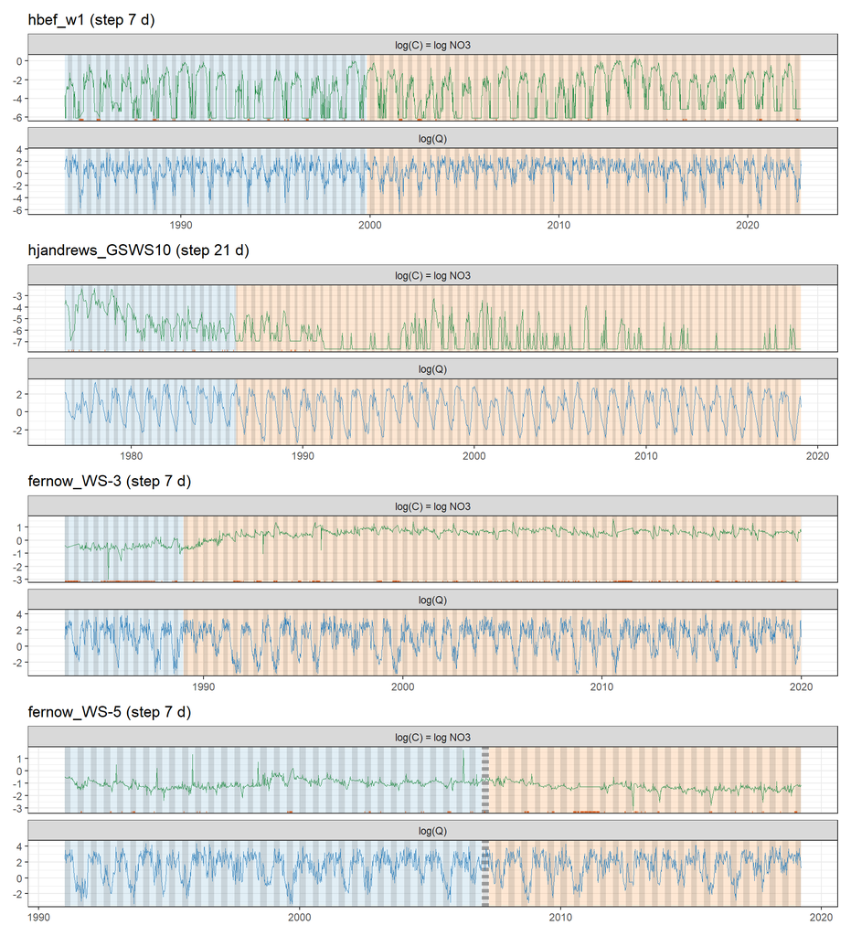

Figure 2. C→Q assembled series: log(discharge) (blue) and log(nitrate) (green) on each site’s native grid; interpolated (no-sample) bins marked, pre/post shaded, dashed = disturbance. Note the coarser hjandrews grid and fernow’s flagged gap.

```r
cq_panel <- function(s) {
  bands <- s %>% filter(phase != "disturbance") %>% group_by(phase) %>%
    summarise(xmin = min(date), xmax = max(date), .groups = "drop")
  td <- s$date[s$phase == "disturbance"]
  long <- s %>% transmute(date, `log(Q)` = log(Q), `log(C) = log NO3` = log(C), C_interp) %>%
    pivot_longer(c(`log(Q)`, `log(C) = log NO3`), names_to = "var")
  ggplot() +
    geom_rect(data = bands, aes(xmin = xmin, xmax = xmax, ymin = -Inf, ymax = Inf, fill = phase),
              alpha = 0.30, inherit.aes = FALSE) +
    season_layer(s, "date") +
    geom_vline(xintercept = td, linetype = 2, colour = "grey60") +
    geom_line(data = long, aes(date, value, colour = var), linewidth = 0.2) +
    geom_rug(data = filter(long, C_interp, var == "log(C) = log NO3"),
             aes(x = date), sides = "b", colour = "#d94801", alpha = 0.5, length = unit(0.03, "npc")) +
    facet_wrap(~ var, ncol = 1, scales = "free_y") +
    scale_fill_manual(values = c(pre = "#9ecae1", disturbance = "grey45", post = "#fdae6b"), guide = "none") +
    scale_colour_manual(values = c(`log(Q)` = "#3182bd", `log(C) = log NO3` = "#238b45"), guide = "none") +
    labs(title = sprintf("%s (step %d d)", s$site[1], s$step_days[1]), x = NULL, y = NULL)
}
wrap_plots(lapply(cq, cq_panel), ncol = 1)
```

The `*__series_daily.csv` (five, P→Q) and `*__cq_native.csv` (four, C→Q) files are the **only tracked interface** between this prep and the analyses — exactly as `synthetic_*.csv` are for `syn_data`. Regenerate them by knitting this notebook (it reads `../data/` + `../qualifying_disturbances.csv`, which require the local MacroSheds pull but are not needed to *run* 03/04/05). ```